# Plotting bi-objective models

### Example 2

We define the model $\max \{cx | Ax \leq b\}$ (could also be minimized) with three variables:

```r
A <- matrix( c(
   -1, 1, 0,
   1, 4, 0,
   2, 1, 0,
   3, -4, 0,
   0, 0, 4
), nc = 3, byrow = TRUE)
b <- c(5, 45, 27, 24, 10)
obj <- matrix(c(1, -6, 3, -4, 1, 6), nrow = 2)
```

We load the preferred view angle for the RGL window:

```r
view <- matrix( c(0.976349174976349, -0.202332556247711, 0.0761845782399178, 0, 0.0903248339891434,
                  0.701892614364624, 0.706531345844269, 0, -0.196427255868912, -0.682940244674683,
                  0.703568696975708, 0, 0, 0, 0, 1), nc = 4)
loadView(v = view)
```

LP model (solution space):

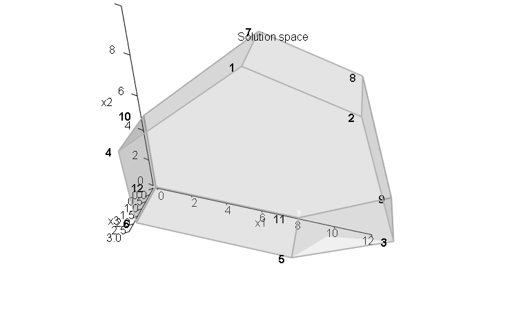

```r
plotSol(A, b)
```

LP model (criterion space):

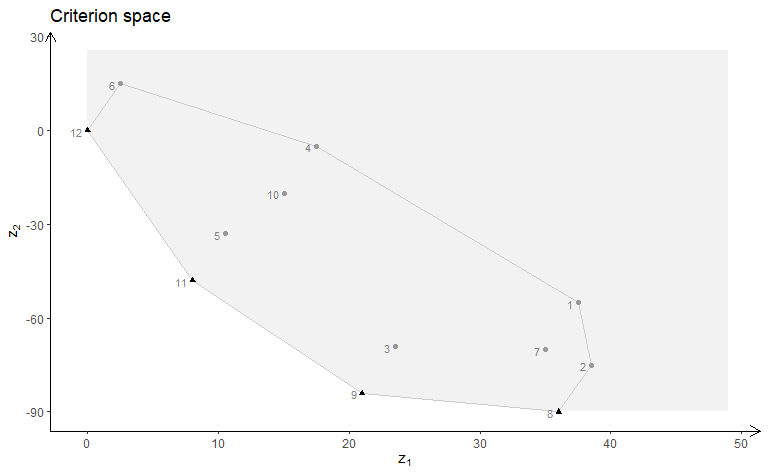

```r
plotCrit(A, b, obj, addTriangles = FALSE)
```

ILP model (solution space):

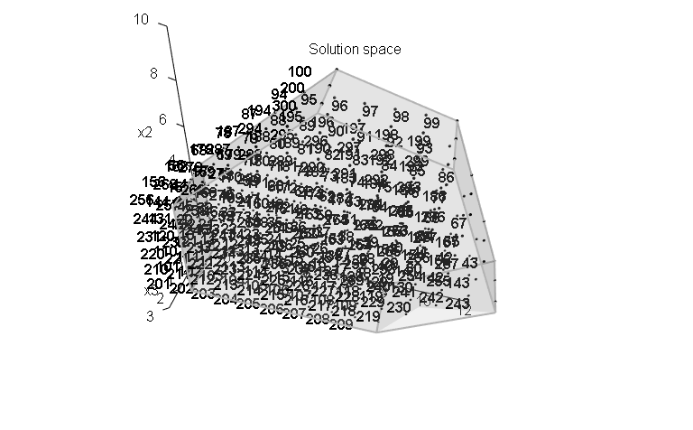

```r
plotSol(A, b, type = c("i","i","i"))
```

ILP model (criterion space):

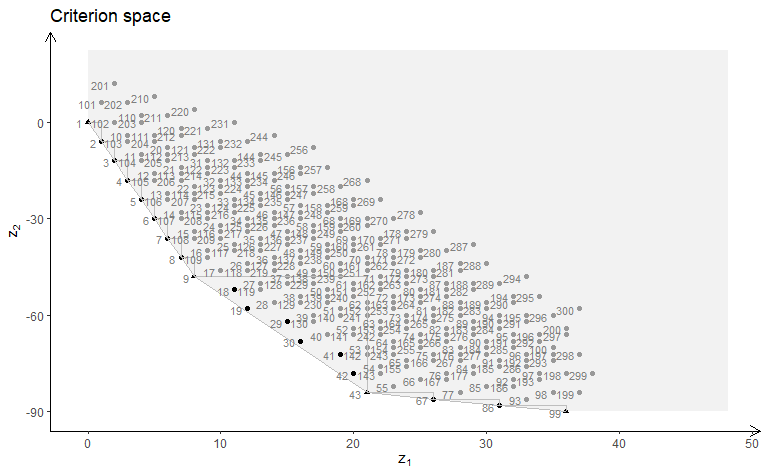

```r
plotCrit(A, b, obj, type = c("i","i","i"))
```

MILP model with variable 2 and 3 integer (solution space):

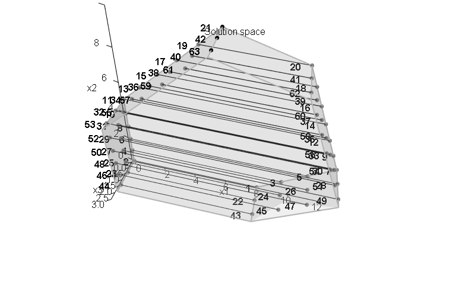

```r
plotSol(A, b, type = c("c","i","i"))
```

MILP model with variable 2 and 3 integer (criterion space):

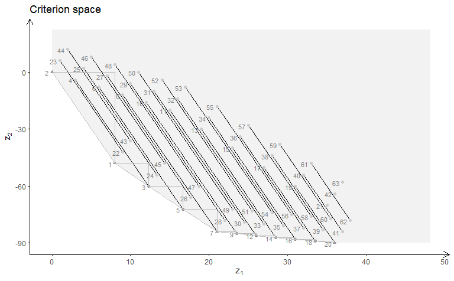

```r
plotCrit(A, b, obj, type = c("c","i","i"))
```

MILP model with variable 1 and 3 integer (solution space):

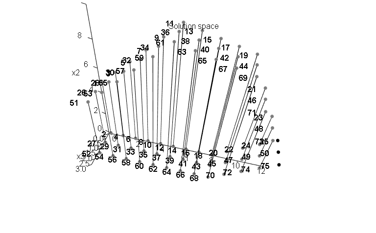

```r
plotSol(A, b, type = c("i","c","i"), plotFaces = FALSE)
```

MILP model with variable 1 and 3 integer (criterion space):

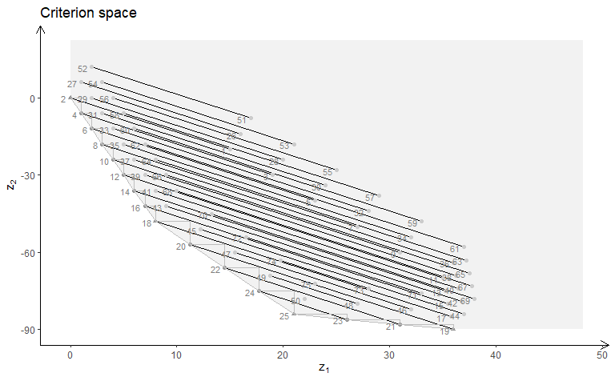

```r
plotCrit(A, b, obj, type = c("i","c","i"))
```

MILP model with variable 1 and 2 integer (solution space):

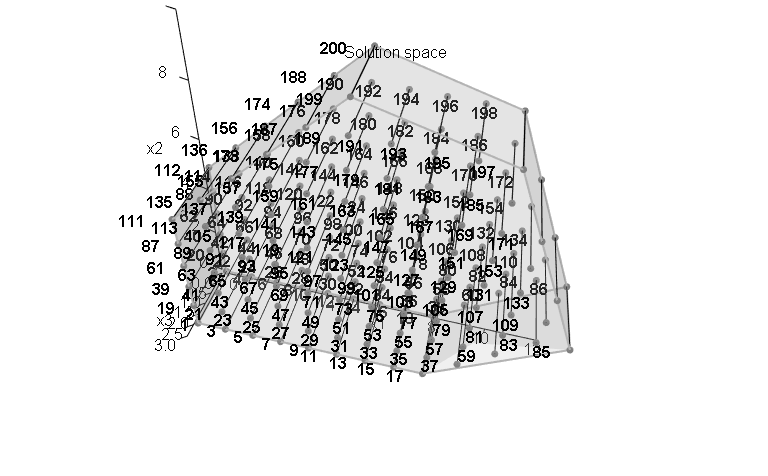

```r
plotSol(A, b, type = c("i","i","c"))
```

MILP model with variable 1 and 2 integer (criterion space):

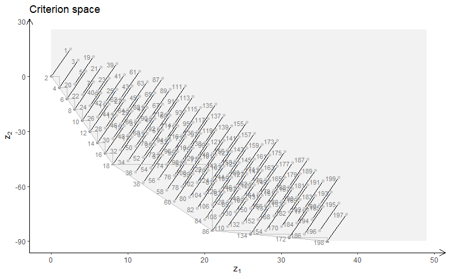

```r
plotCrit(A, b, obj, type = c("i","i","c"))
```

MILP model with variable 1 integer (solution space):

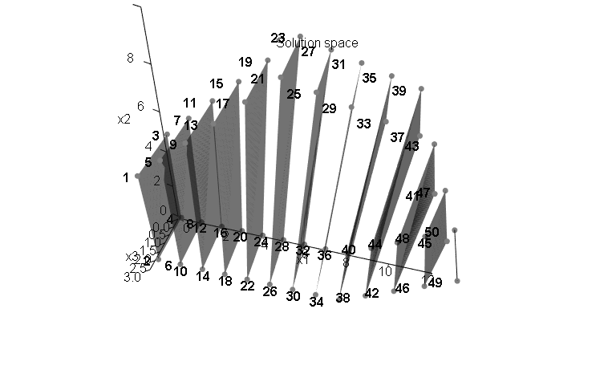

```r
plotSol(A, b, type = c("i","c","c"), plotFaces = F)
```

MILP model with variable 1 integer (criterion space):

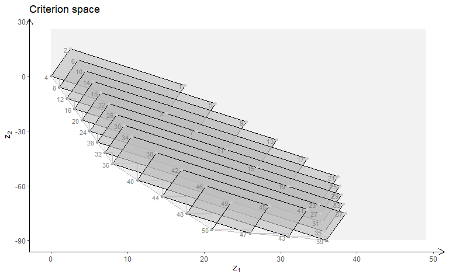

```r
plotCrit(A, b, obj, type = c("i","c","c"))
```

MILP model with variable 2 integer (solution space - interactive plot):

```r
plotSol(A, b, type = c("c","i","c"), plotFaces = F)
```

[interactive chart not shown]

MILP model with variable 2 integer (criterion space):

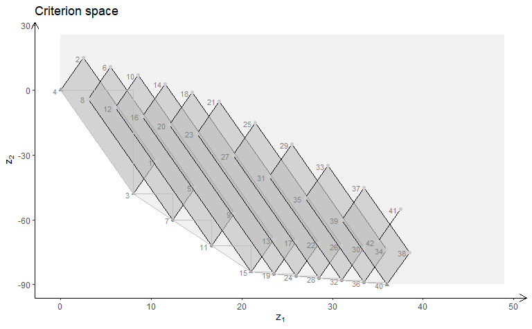

```r
plotCrit(A, b, obj, type = c("c","i","c"))
```

MILP model with variable 3 integer (solution space - Interactive plot):

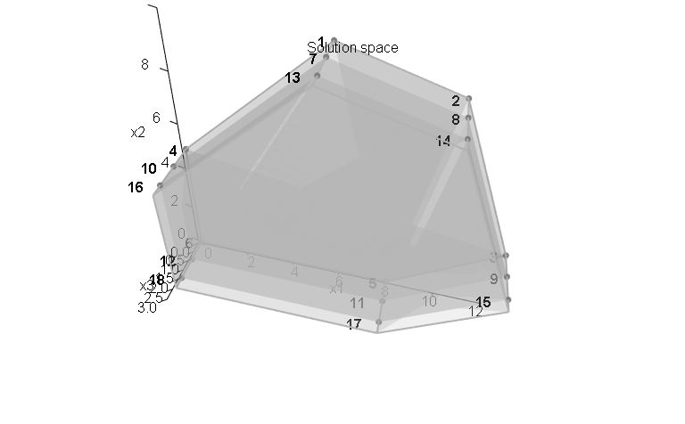

```r
plotSol(A, b, type = c("c","c","i"))
```

MILP model with variable 3 integer (criterion space):

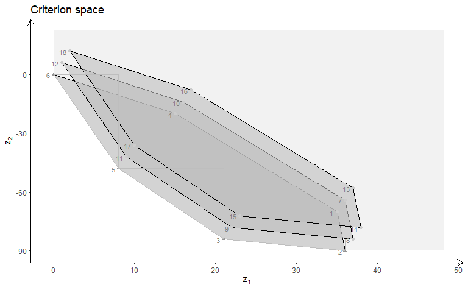

```r
plotCrit(A, b, obj, type = c("c","c","i"))
```

### Example 3

We define the model $\max \{cx | Ax \leq b\}$ (could also be minimized) with three variables:

```r
A <- matrix( c(
   1, 1, 1,
   3, 0, 1
), nc = 3, byrow = TRUE)
b <- c(10, 24)
obj <- matrix(c(1, -6, 3, -4, 1, 6), nrow = 2)
```

We load the preferred view angle for the RGL window:

```r
view <- matrix( c(-0.812462985515594, -0.029454167932272, 0.582268416881561, 0, 0.579295456409454,
                  -0.153386667370796, 0.800555109977722, 0, 0.0657325685024261, 0.987727105617523,
                  0.14168381690979, 0, 0, 0, 0, 1), nc = 4)
loadView(v = view)
```

LP model (solution space):

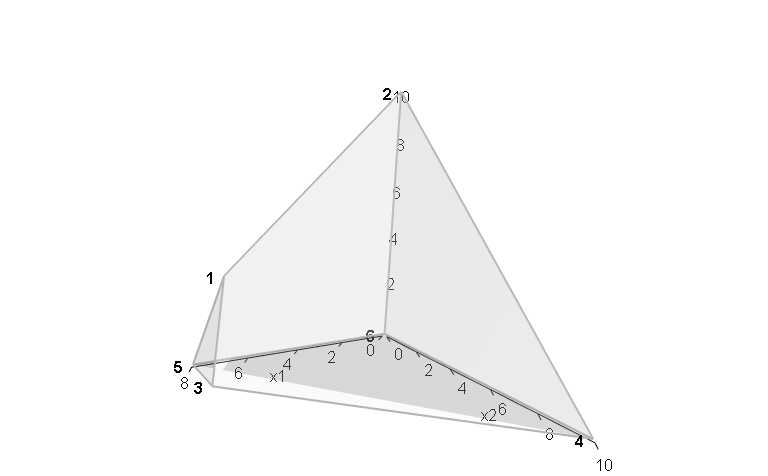

```r
plotSol(A, b)
```

LP model (criterion space):

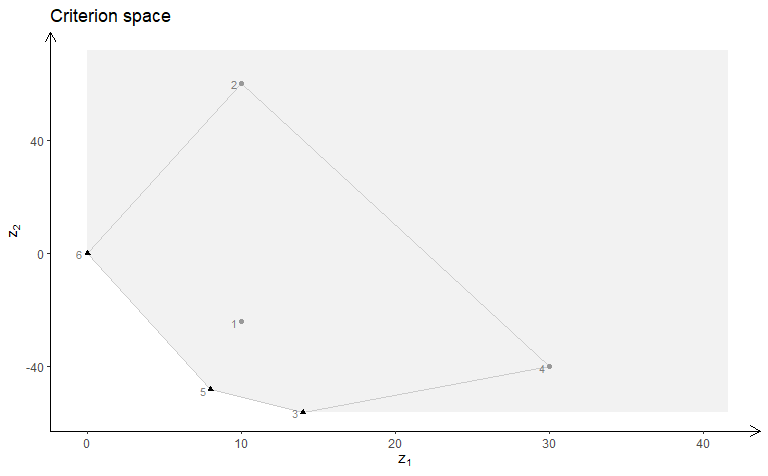

```r
plotCrit(A, b, obj, addTriangles = FALSE)
```

ILP model (solution space):

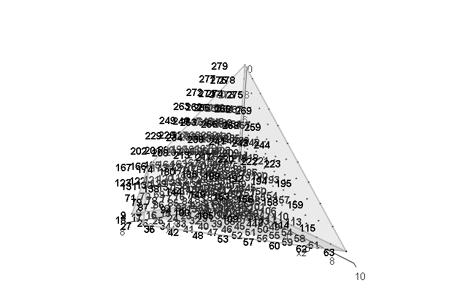

```r
plotSol(A, b, type = c("i","i","i"))
```

ILP model (criterion space):

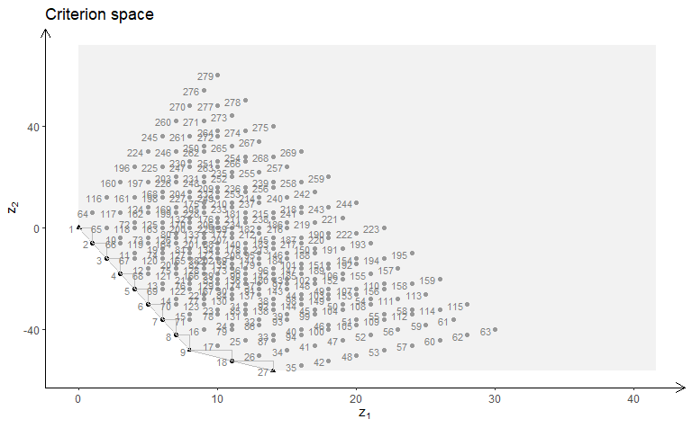

```r
plotCrit(A, b, obj, type = c("i","i","i"))
```

MILP model with variable 2 and 3 integer (solution space):

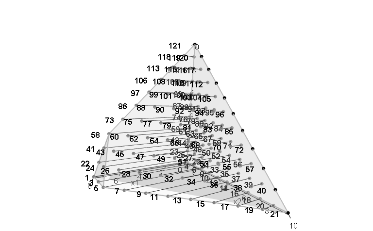

```r
plotSol(A, b, type = c("c","i","i"))
```

MILP model with variable 2 and 3 integer (criterion space):

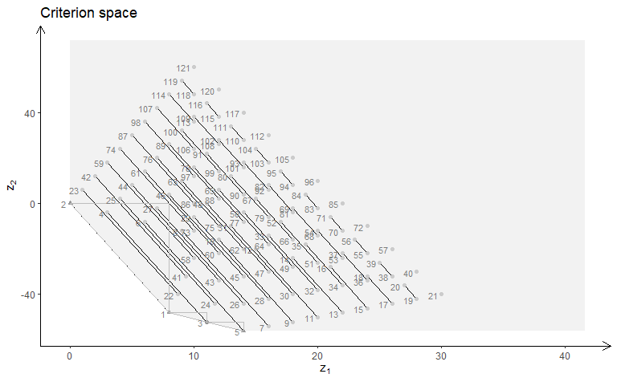

```r
plotCrit(A, b, obj, type = c("c","i","i"))
```

MILP model with variable 1 and 3 integer (solution space):

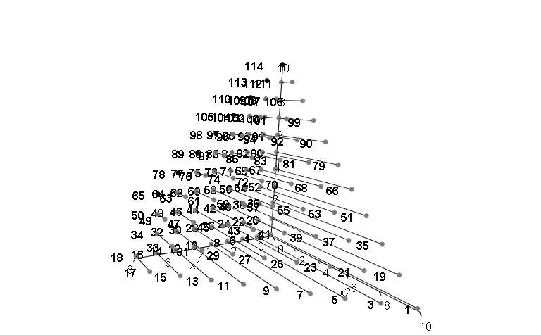

```r
plotSol(A, b, type = c("i","c","i"), plotFaces = FALSE)
```

MILP model with variable 1 and 3 integer (criterion space):

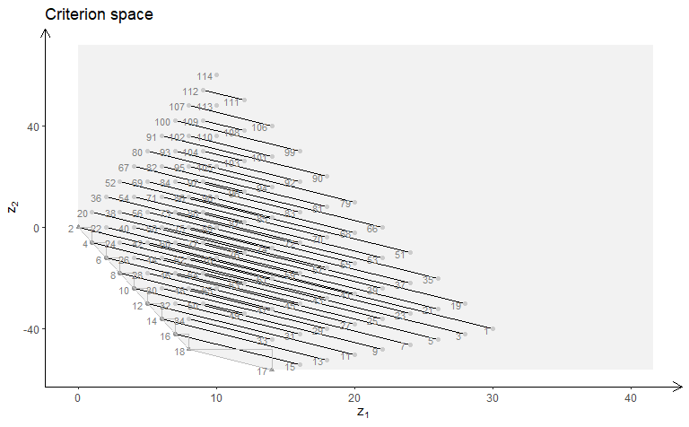

```r
plotCrit(A, b, obj, type = c("i","c","i"))
```

MILP model with variable 1 and 2 integer (solution space):

```r
plotSol(A, b, type = c("i","i","c"))
```

[output not shown]

MILP model with variable 1 and 2 integer (criterion space):

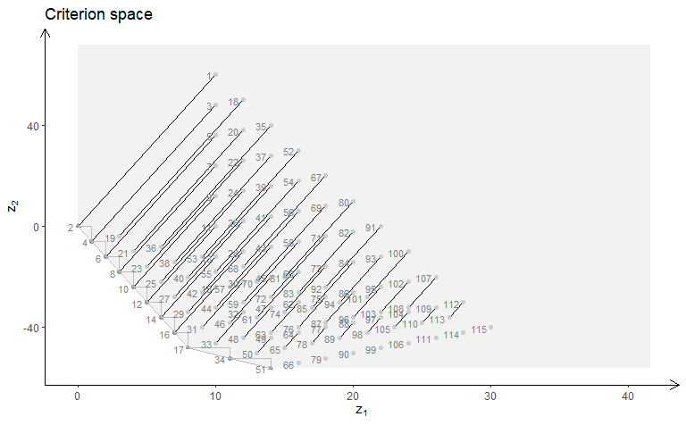

```r
plotCrit(A, b, obj, type = c("i","i","c"))
```

MILP model with variable 1 integer (solution space):

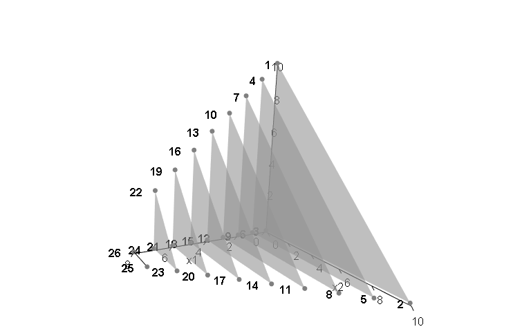

```r
plotSol(A, b, type = c("i","c","c"), plotFaces = F)
```

MILP model with variable 1 integer (criterion space):

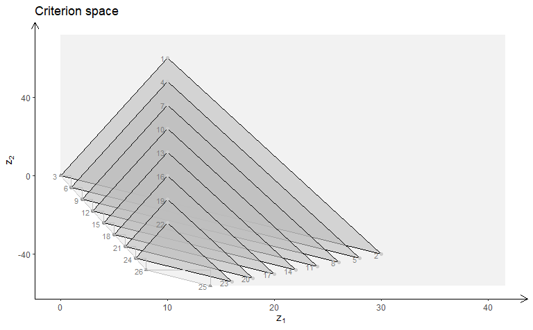

```r
plotCrit(A, b, obj, type = c("i","c","c"))
```

MILP model with variable 2 integer (solution space):

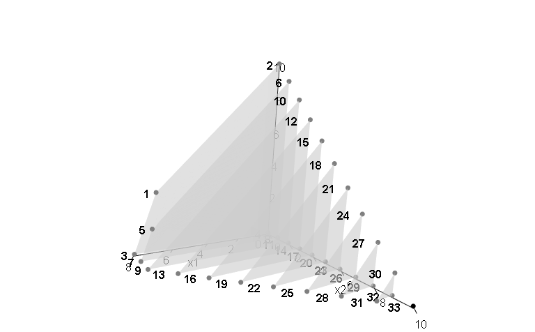

```r
plotSol(A, b, type = c("c","i","c"), plotFaces = F)
```

MILP model with variable 2 integer (criterion space):

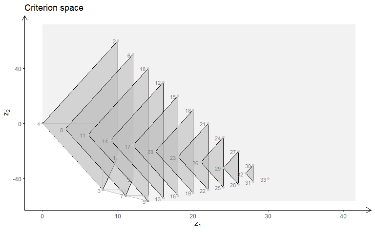

```r
plotCrit(A, b, obj, type = c("c","i","c"))
```

MILP model with variable 3 integer (solution space - Interactive plot):

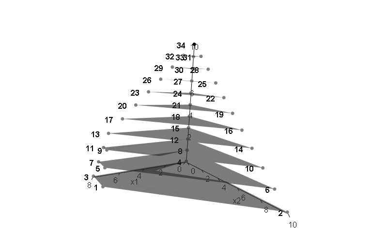

```r
plotSol(A, b, type = c("c","c","i"), plotFaces = F)
```

MILP model with variable 3 integer (criterion space):

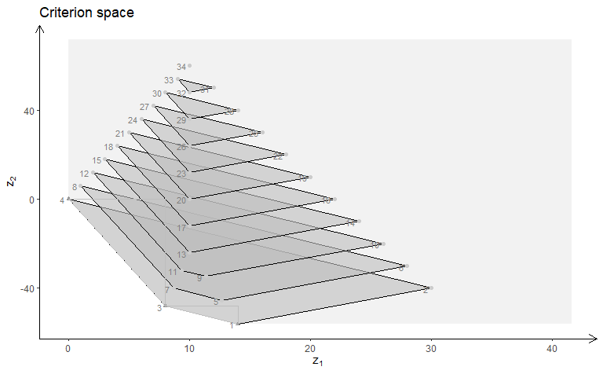

```r
plotCrit(A, b, obj, type = c("c","c","i"))
```

### Example 4

We define the model $\max \{cx | Ax \leq b\}$ (could also be minimized) with three variables:

```r
A <- matrix( c(
3, 2, 5,
2, 1, 1,
1, 1, 3,
5, 2, 4
), nc = 3, byrow = TRUE)
b <- c(55, 26, 30, 57)
obj <- matrix(c(1, -6, 3, -4, 1, -1), nrow = 2)
```

We load the preferred view angle for the RGL window:

```r
view <- matrix( c(-0.412063330411911, -0.228006735444069, 0.882166087627411, 0, 0.910147845745087,
                  -0.0574885793030262, 0.410274744033813, 0, -0.042830865830183, 0.97196090221405,
                  0.231208890676498, 0, 0, 0, 0, 1), nc = 4)
loadView(v = view)
```

LP model (solution space):

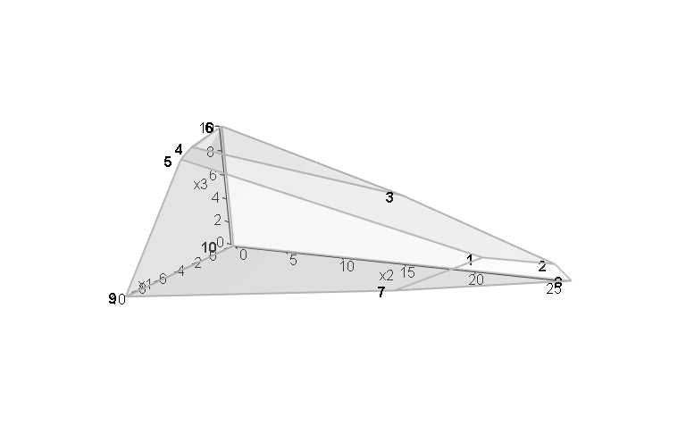

```r
plotSol(A, b)
```

LP model (criterion space):

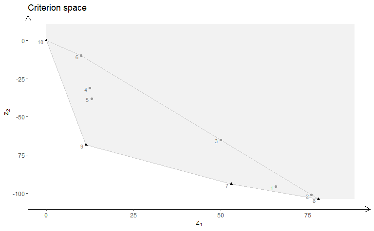

```r
plotCrit(A, b, obj, addTriangles = FALSE)
```

ILP model (solution space):

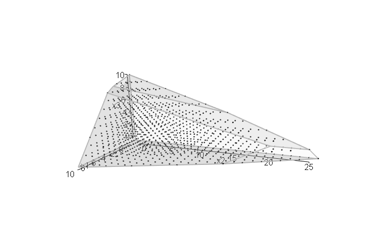

```r
plotSol(A, b, type = c("i","i","i"), labels="n")
```

ILP model (criterion space):

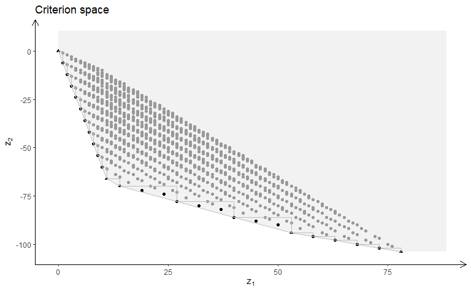

```r
plotCrit(A, b, obj, type = c("i","i","i"), labels="n")
```

MILP model with variable 2 and 3 integer (solution space):

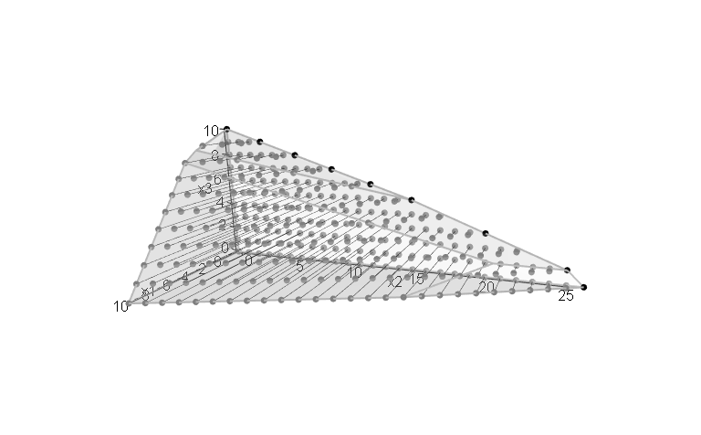

```r
plotSol(A, b, type = c("c","i","i"), labels="n")
```

MILP model with variable 2 and 3 integer (criterion space):

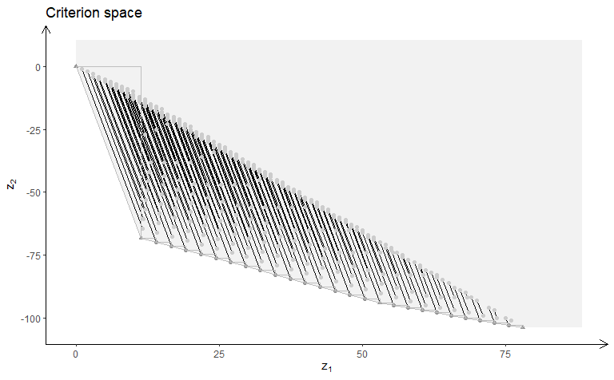

```r
plotCrit(A, b, obj, type = c("c","i","i"), labels="n")
```

MILP model with variable 1 and 3 integer (solution space):

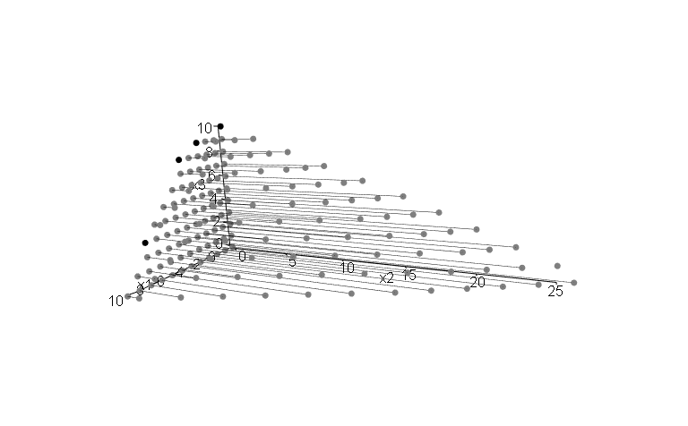

```r
plotSol(A, b, type = c("i","c","i"), plotFaces = FALSE, labels="n")
```

MILP model with variable 1 and 3 integer (criterion space):

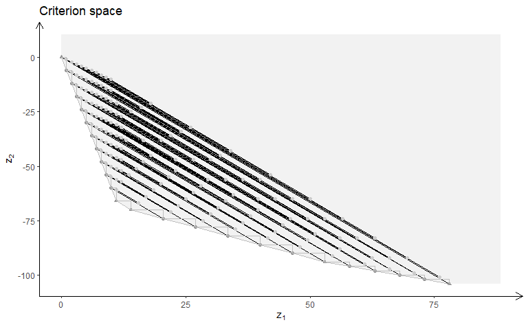

```r
plotCrit(A, b, obj, type = c("i","c","i"), labels="n")
```

MILP model with variable 1 and 2 integer (solution space):

```r
plotSol(A, b, type = c("i","i","c"), labels="n")
```

[output not shown]

MILP model with variable 1 and 2 integer (criterion space):

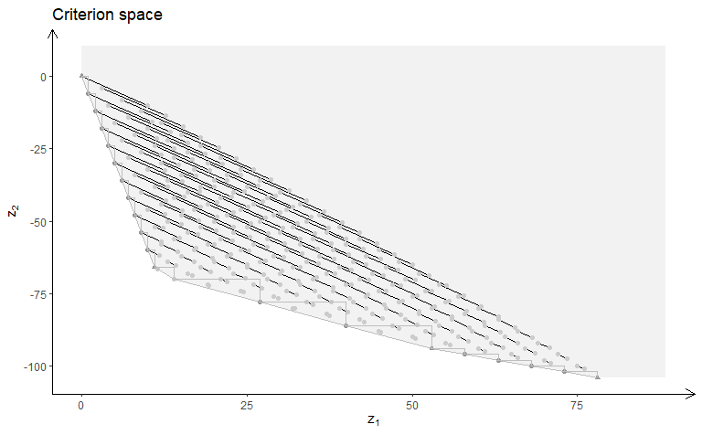

```r
plotCrit(A, b, obj, type = c("i","i","c"), labels="n")
```

MILP model with variable 1 integer (solution space):

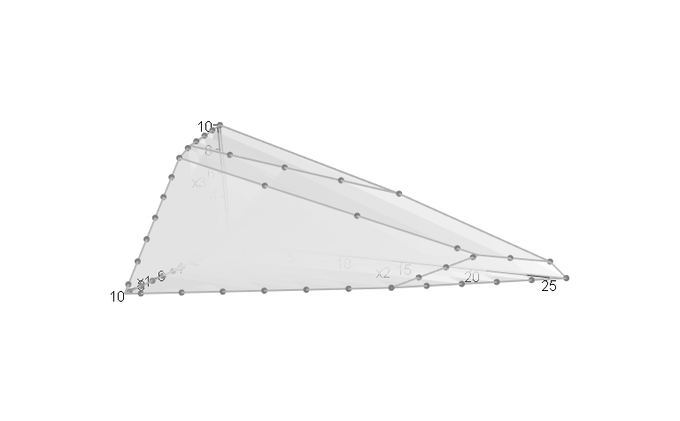

```r
plotSol(A, b, type = c("i","c","c"), labels="n")
```

MILP model with variable 1 integer (criterion space):

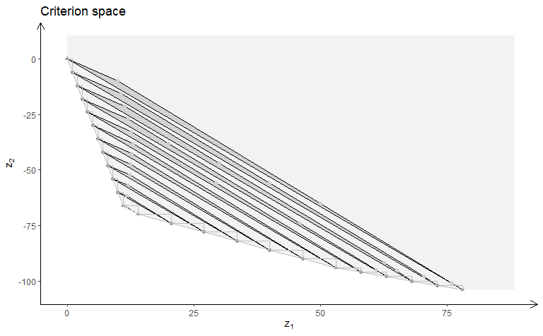

```r
plotCrit(A, b, obj, type = c("i","c","c"), labels="n")
```

MILP model with variable 2 integer (solution space):

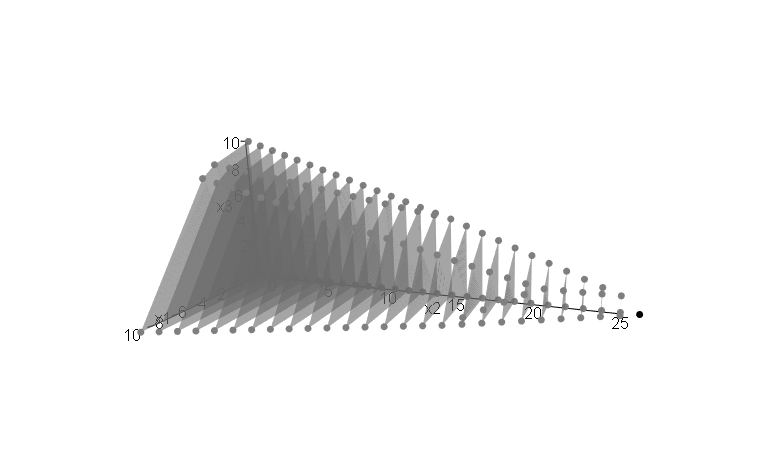

```r
plotSol(A, b, type = c("c","i","c"), plotFaces = F, labels="n")
```

MILP model with variable 2 integer (criterion space):

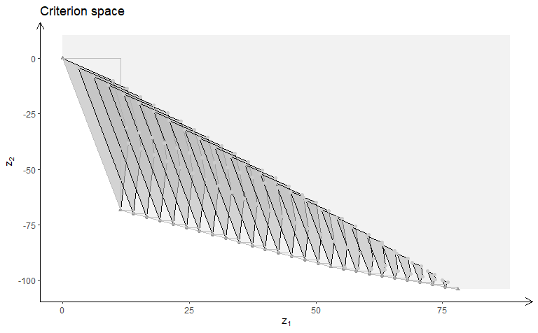

```r
plotCrit(A, b, obj, type = c("c","i","c"), labels="n")
```

MILP model with variable 3 integer (solution space - Interactive plot):

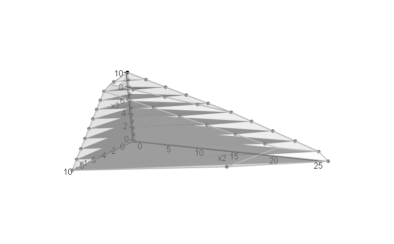

```r
plotSol(A, b, type = c("c","c","i"), labels="n")
```

MILP model with variable 3 integer (criterion space):

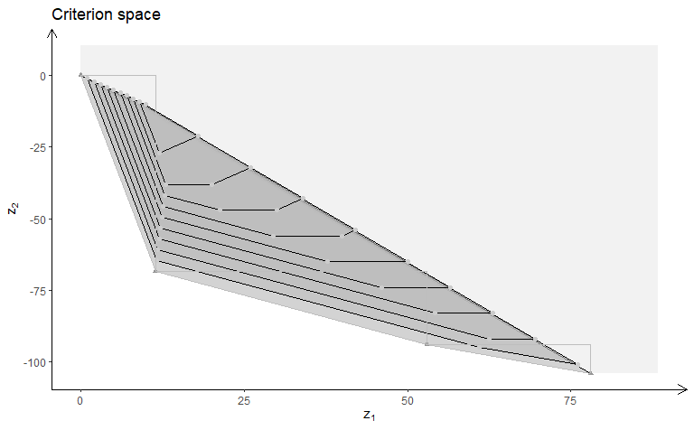

```r
plotCrit(A, b, obj, type = c("c","c","i"), labels="n")
```